### Objective: Evaluate whether harvest influences presence (or biomass) of a species

```r
#setwd("/Users/rebeccaselden/Documents/Collaborations/FishClim")
surv.dat <- readRDS("Data/dat.latbin2.rds")
land.dat <- readRDS("Data/total.land.latbin.rds")
setorder(land.dat, spp, year)
```

### Examine relationship between latitude and SBT

Very strong sigmoid relationship between SBT and latitude Very strong linear relationship between SST and latitude Not a surprise that these two variables no longer significant when have spatial fixed effects –> Clarification from meeting with Malin, the spatial trends in temperature will be soaked up by spatial fixed effects, but the temporal variation in temperature is what will be evaluated (which is what we specifically want to evaluate for climate change)

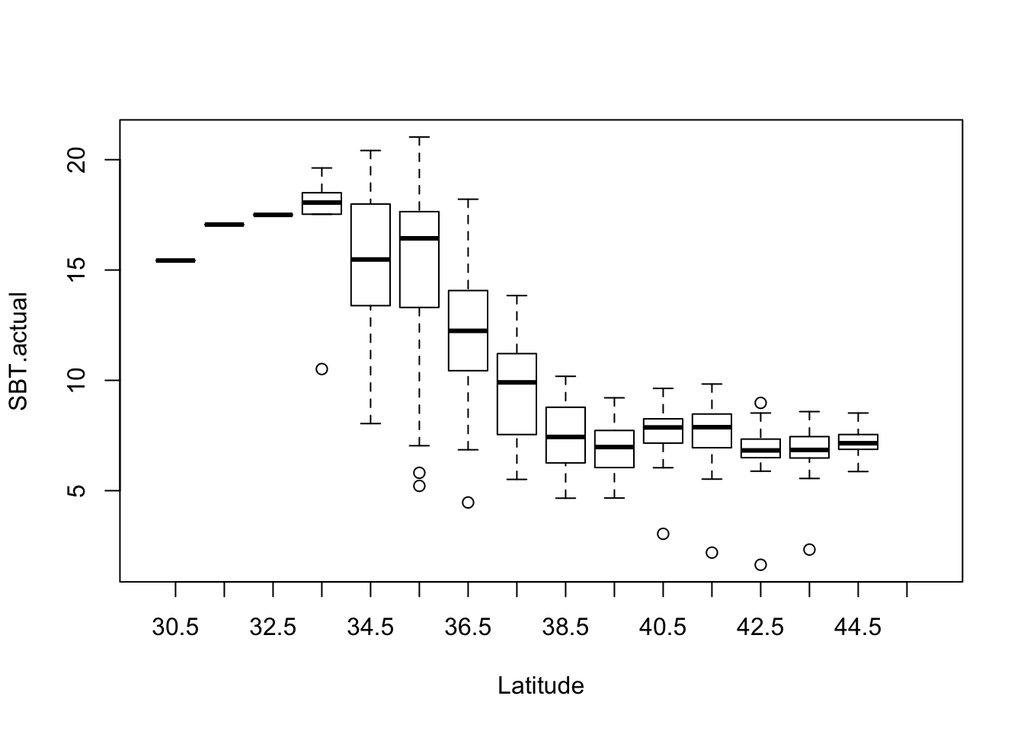

```r
boxplot(SBT.actual ~ lat.bin, surv.dat[spp=="Clupea harengus"], xlab="Latitude", ylab="SBT.actual")
```

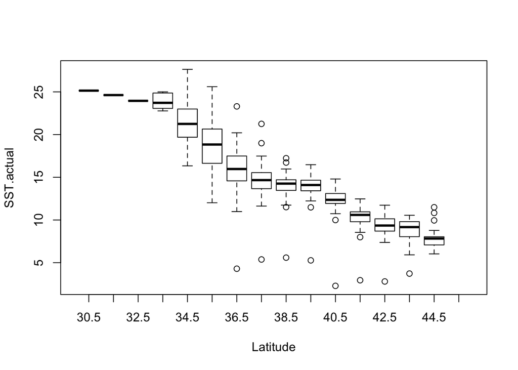

```r
boxplot(SST.actual ~ lat.bin, surv.dat[spp=="Clupea harengus"], xlab="Latitude", ylab="SST.actual")
```

### Assign catch=0 for areas surveyed and no catch observed

Make sure each species has a landing record for each year and lat bin in the survey Get rid of southernmost survey bins because not observed in every year

```r
combined.dat <- merge(surv.dat[!(is.na(lat.bin))& year<2015 &!(lat.bin %in% c("30.5", "31.5", "32.5", "33.5", "34.5"))],
                      land.dat, by=c("lat.bin", "year", "spp"), all.x=T)
setorder(combined.dat, spp, year, lat.bin)

combined.dat[,"land_mt":=ifelse(is.na(tl_mt), 0, tl_mt)]
```

### Standardize catch so mean of 0 and sd=1 within a species

If no catch in any year, give value of 0

```r
catch.scale <- combined.dat[,list(mean_land=mean(land_mt, na.rm=T), sd_land=sd(land_mt, na.rm=T)), by=list(spp)]
combined.dat2 <- merge(combined.dat, catch.scale, by="spp")

combined.dat2[,"land_scaled":=ifelse(mean_land==0, 0, scale(land_mt, center=T, scale=T)), by=list(spp)]

#land_yr <- combined.dat2[,list(mean_land=mean(land_mt), mean_land_scaled=mean(land_scaled)), by=list(spp, year)]
```

### Standardize Temperature within spp

Normalize each temperature for each species range to a mean of 0 and SD of 1 across spp geo range. Subtract its mean temperature of occurrence (or of biomass) from the observed temperature. Then divide by standard deviation of temperature of occurrence (or of biomass)

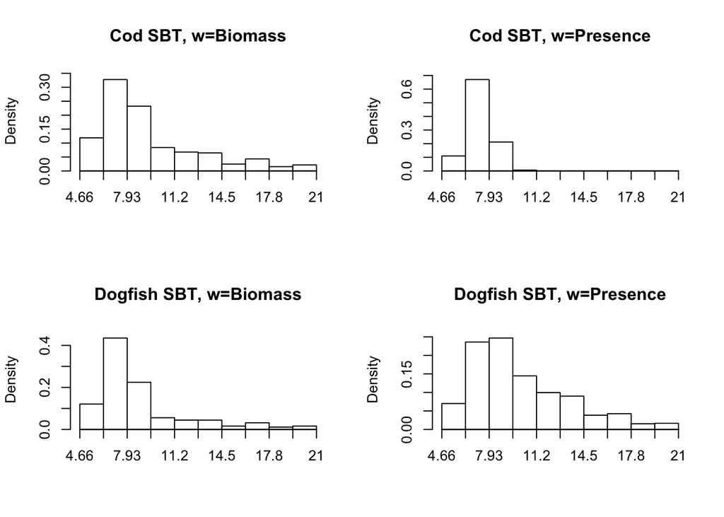

```r
par(mfrow=c(2,2))
weighted.hist(combined.dat2[spp=="Gadus morhua"]$SBT.actual,
              w=combined.dat2[spp=="Gadus morhua"]$wtcpuenal, freq=F, main="Cod SBT, w=Biomass")
weighted.hist(combined.dat2[spp=="Gadus morhua"]$SBT.actual,
              w=combined.dat2[spp=="Gadus morhua"]$pres2, freq=F, main="Cod SBT, w=Presence")
weighted.hist(combined.dat2[spp=="Centropristis striata"]$SBT.actual,
              w=combined.dat2[spp=="Centropristis striata"]$wtcpuenal, freq=F, main="Dogfish SBT, w=Biomass")
weighted.hist(combined.dat2[spp=="Centropristis striata"]$SBT.actual,
              w=combined.dat2[spp=="Centropristis striata"]$pres2, freq=F, main="Dogfish SBT, w=Presence")
```

Calculate mean SBT and SST of presence weighted by presence and biomass

```r
combined.dat2[,"mean.SBTpres":=weighted.mean(SBT.actual, w=pres2), by=list(spp)]
combined.dat2[,"mean.SSTpres":=weighted.mean(SST.actual, w=pres2), by=list(spp)]

combined.dat2[,"sd.SBTpres":=sqrt(wtd.var(SBT.actual, weights=pres2)), by=list(spp)]
combined.dat2[,"sd.SSTpres":=sqrt(wtd.var(SST.actual, weights=pres2)), by=list(spp)]

combined.dat2[,"mean.SBTbio":=weighted.mean(SBT.actual, w=wtcpuenal), by=list(spp)]
combined.dat2[,"mean.SSTbio":=weighted.mean(SST.actual, w=wtcpuenal), by=list(spp)]

combined.dat2[,"sd.SBTbio":=sqrt(wtd.var(SBT.actual, weights=wtcpuenal)), by=list(spp)]
```

[output not shown]

[output cut: 307 more lines]

[output not shown]

```r
combined.dat2[,"sd.SSTbio":=sqrt(wtd.var(SST.actual, weights=wtcpuenal)), by=list(spp)]
```

[output not shown]

[output cut: 304 more lines]

[output not shown]

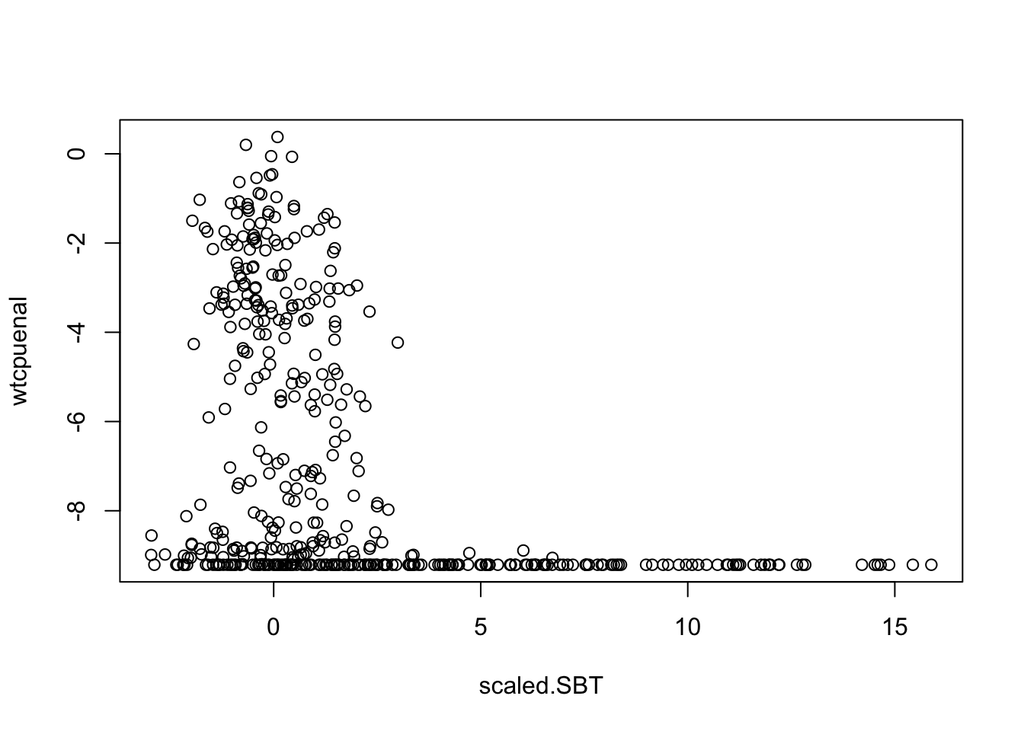

```r
combined.dat2[,"scaled.SBT":=(SBT.actual - mean.SBTpres)/sd.SBTpres]
combined.dat2[,"scaled.SST":=(SST.actual - mean.SSTpres)/sd.SSTpres]

plot(wtcpuenal ~ scaled.SBT, combined.dat2[spp=="Gadus morhua"])
```

### Lag variables in time

Lag catch, biomass, presence, and environment by one, two, and 3 year

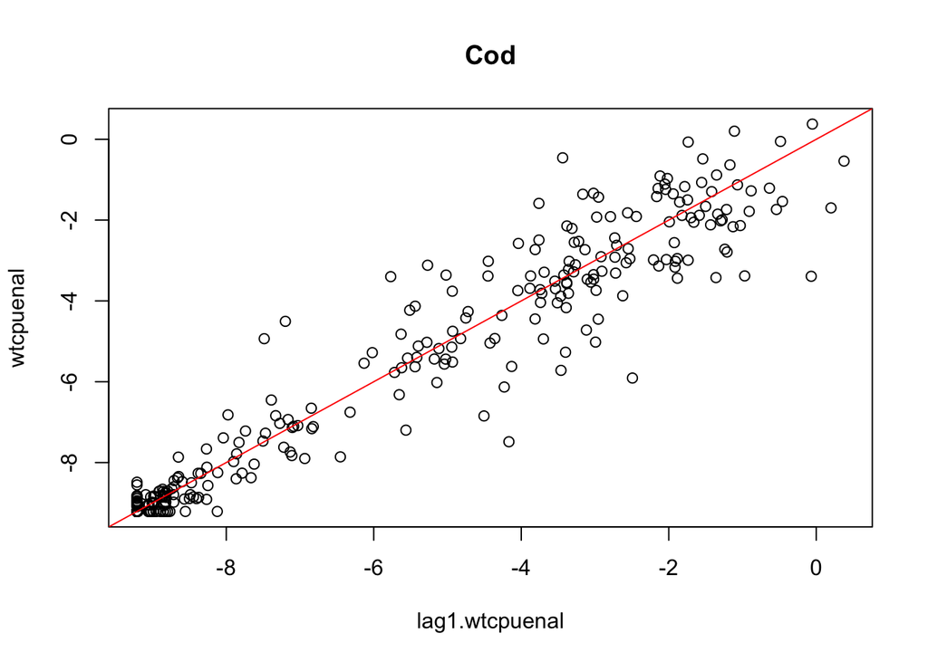

```r
vars <- c("pres2", "wtcpue", "wtcpuenal", "land_mt", "land_scaled",
          "scaled.SBT", "avg.SBT.min", "avg.SBT.max",
          "scaled.SST", "avg.SST.min", "avg.SST.max")
lag1cols <- paste("lag1", vars, sep=".")
lag2cols <- paste("lag2", vars, sep=".")
lag3cols <- paste("lag3", vars, sep=".")

lag.dt <- copy(combined.dat2)

lag.dt[,(lag1cols):=shift(.SD, n=1, type="lag"), by=list(spp, lat.bin), .SDcols=vars]
lag.dt[,(lag2cols):=shift(.SD, n=2, type="lag"), by=list(spp, lat.bin), .SDcols=vars]
lag.dt[,(lag3cols):=shift(.SD, n=3, type="lag"), by=list(spp, lat.bin), .SDcols=vars]



### Examine autocorrelation in biomass
plot(wtcpuenal ~ lag1.wtcpuenal, lag.dt[spp=="Gadus morhua"], main="Cod")
abline(a=0, b=1, col="red")
```

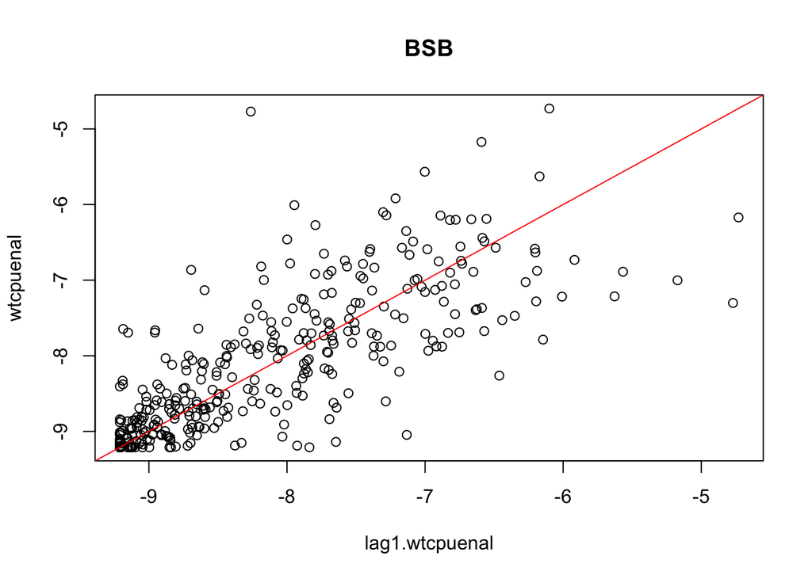

```r
plot(wtcpuenal ~ lag1.wtcpuenal, lag.dt[spp=="Centropristis striata"], main="BSB")
abline(a=0, b=1, col="red")
```

### GAM for Log Bio

Note: depth in a latitude bin does vary by year based on sampling location

Test with BSB

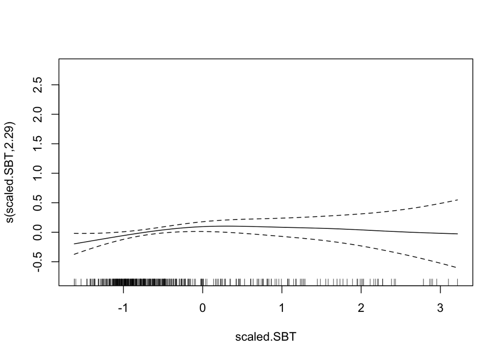

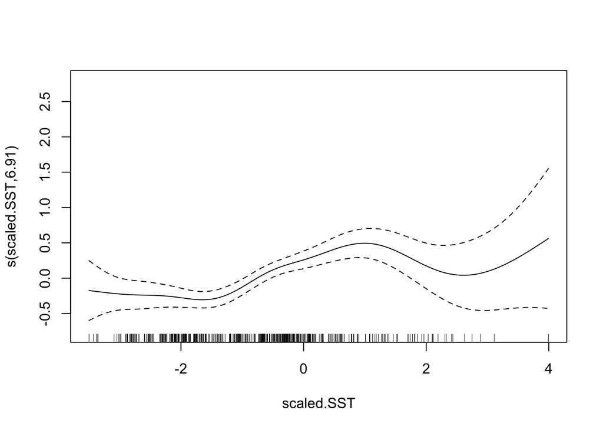

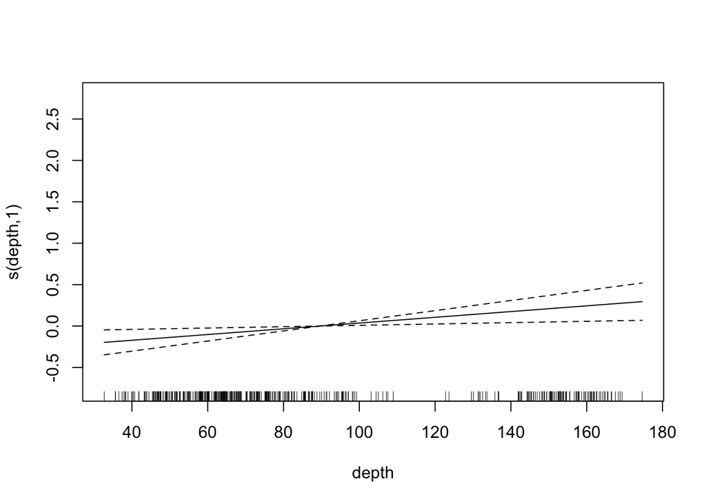

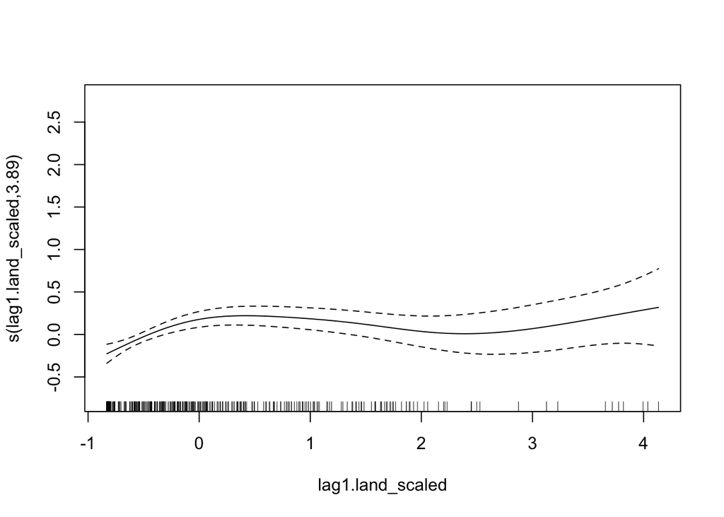

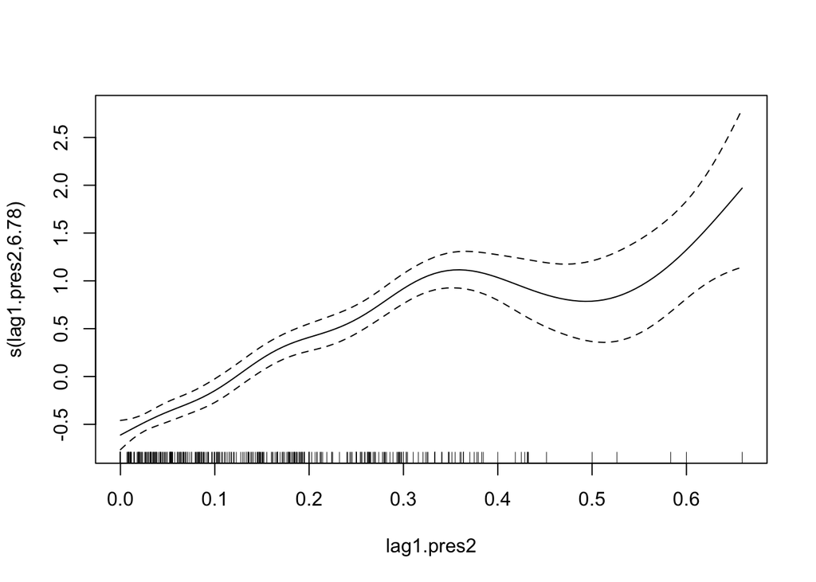

```r
bsb.mod.bio <- gam(wtcpuenal ~ s(scaled.SBT)+ s(scaled.SST)+ s(depth) + s(lag1.land_scaled) + s(lag1.pres2),
                   family=gaussian, data=lag.dt[spp%in%c("Centropristis striata")])
plot(bsb.mod.bio)
```

```r
summary(bsb.mod.bio)
```

```
##
## Family: gaussian
## Link function: identity
##
## Formula:
## wtcpuenal ~ s(scaled.SBT) + s(scaled.SST) + s(depth) + s(lag1.land_scaled) +
##     s(lag1.pres2)
##
## Parametric coefficients:
##             Estimate Std. Error t value Pr(>|t|)
## (Intercept)  -8.2950     0.0238  -348.5   <2e-16 ***
## ---
## Signif. codes:  0 '***' 0.001 '**' 0.01 '*' 0.05 '.' 0.1 ' ' 1
##
## Approximate significance of smooth terms:
##                       edf Ref.df      F  p-value
## s(scaled.SBT)       2.288  2.927  2.610 0.093013 .
## s(scaled.SST)       6.911  8.024  5.727 5.67e-07 ***
## s(depth)            1.000  1.000  6.833 0.009274 **
## s(lag1.land_scaled) 3.891  4.790  4.444 0.000779 ***
## s(lag1.pres2)       6.776  7.881 32.104  < 2e-16 ***
## ---
## Signif. codes:  0 '***' 0.001 '**' 0.01 '*' 0.05 '.' 0.1 ' ' 1
##
## R-sq.(adj) =  0.732   Deviance explained = 74.5%
## GCV = 0.25493  Scale est. = 0.24187   n = 427
```

Linear model with BSB

```r
bsb.lm.bio <- lm(wtcpuenal ~ scaled.SBT + scaled.SST + depth + lag1.land_scaled + lag1.pres2,
                 data=lag.dt[spp=="Centropristis striata"])
summary(bsb.lm.bio)
```

```
##
## Call:
## lm(formula = wtcpuenal ~ scaled.SBT + scaled.SST + depth + lag1.land_scaled +
##     lag1.pres2, data = lag.dt[spp == "Centropristis striata"])
##
## Residuals:
##     Min      1Q  Median      3Q     Max
## -2.2066 -0.2799 -0.0417  0.2181  3.2136
##
## Coefficients:
##                    Estimate Std. Error t value Pr(>|t|)
## (Intercept)      -8.836e+00  1.045e-01 -84.518  < 2e-16 ***
## scaled.SBT       -6.619e-02  4.532e-02  -1.461   0.1449
## scaled.SST        1.583e-01  3.880e-02   4.080 5.38e-05 ***
## depth             4.765e-05  1.081e-03   0.044   0.9649
## lag1.land_scaled  5.822e-02  3.427e-02   1.699   0.0901 .
## lag1.pres2        5.048e+00  2.735e-01  18.458  < 2e-16 ***
## ---
## Signif. codes:  0 '***' 0.001 '**' 0.01 '*' 0.05 '.' 0.1 ' ' 1
##
## Residual standard error: 0.5426 on 421 degrees of freedom
##   (10 observations deleted due to missingness)
## Multiple R-squared:  0.6778, Adjusted R-squared:  0.674
## F-statistic: 177.1 on 5 and 421 DF,  p-value: < 2.2e-16
```

### Mixed Effects GAM for Log Bio

Species as random effect See random effects in mgcv https://stat.ethz.ch/R-manual/R-devel/library/mgcv/html/random.effects.html

Model (log bio) ~ scaled SBT + scaled SST + depth + landings in yr-1 + presence in yr-1 + random(spp)

```r
### All species single model
spplim.mod.bio <- gam(wtcpuenal ~ s(scaled.SBT)+ s(scaled.SST)+ s(depth) + s(lag1.land_scaled) + s(lag1.pres2)+ s(spp, bs="re"),
               family=gaussian, data=lag.dt[spp%in%c("Gadus morhua", "Squalus acanthias", "Limanda ferruginea", "Centropristis striata")])
summary(spplim.mod.bio)
```

```
##
## Family: gaussian
## Link function: identity
##
## Formula:
## wtcpuenal ~ s(scaled.SBT) + s(scaled.SST) + s(depth) + s(lag1.land_scaled) +
##     s(lag1.pres2) + s(spp, bs = "re")
##
## Parametric coefficients:
##             Estimate Std. Error t value Pr(>|t|)
## (Intercept) -5.38039    0.01848  -291.2   <2e-16 ***
## ---
## Signif. codes:  0 '***' 0.001 '**' 0.01 '*' 0.05 '.' 0.1 ' ' 1
##
## Approximate significance of smooth terms:
##                       edf Ref.df        F  p-value
## s(scaled.SBT)       1.871  2.382    9.325 7.37e-05 ***
## s(scaled.SST)       6.103  7.346   13.092  < 2e-16 ***
## s(depth)            1.000  1.000   13.734 0.000217 ***
## s(lag1.land_scaled) 2.046  2.568   12.131 8.50e-07 ***
## s(lag1.pres2)       1.000  1.000 1561.442  < 2e-16 ***
## s(spp)              3.200  4.000  143.520  < 2e-16 ***
## ---
## Signif. codes:  0 '***' 0.001 '**' 0.01 '*' 0.05 '.' 0.1 ' ' 1
##
## Rank: 49/50
## R-sq.(adj) =   0.86   Deviance explained = 86.1%
## GCV = 0.9197  Scale est. = 0.91107   n = 1708
```

```r
gam.vcomp(spplim.mod.bio)
```

```
##       s(scaled.SBT)       s(scaled.SST)            s(depth)
##        1.972078e-02        2.586233e-01        1.516409e-08
## s(lag1.land_scaled)       s(lag1.pres2)              s(spp)
##        8.476525e-02        2.567500e-05        5.296522e+03
```

### Beta Regression for Presence

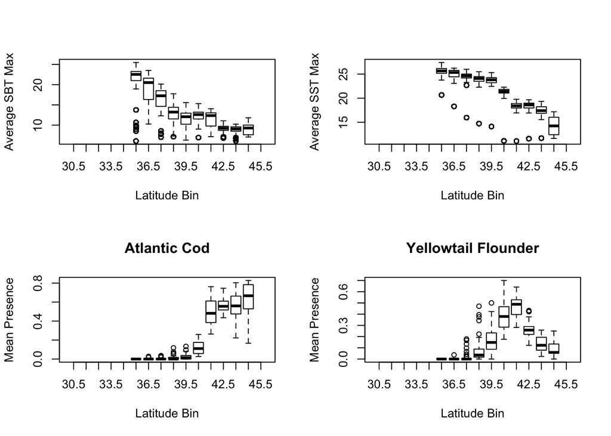

```r
### To use beta regression, need pres2 to be (0,1)
lag.dt[,"pres2_beta":=ifelse(pres2==0, 0.00001, ifelse(pres2==1, 0.99999, pres2))]

par(mfrow=c(2,2))
plot(avg.SBT.max ~ lat.bin, lag.dt, ylab="Average SBT Max", xlab="Latitude Bin")
plot(avg.SST.max ~ lat.bin, lag.dt, ylab="Average SST Max", xlab="Latitude Bin")
boxplot(pres2 ~ lat.bin, lag.dt[spp=="Gadus morhua"], main="Atlantic Cod",
        ylab="Mean Presence", xlab="Latitude Bin")
boxplot(pres2 ~ lat.bin, lag.dt[spp=="Limanda ferruginea"], main="Yellowtail Flounder",
        ylab="Mean Presence", xlab="Latitude Bin")
```

```r
# par(mfrow=c(3,2))
# plot(pres2 ~ avg.SST.max, lag.dtN[spp=="Gadus morhua"], main="Atlantic Cod",
#      ylab="Mean Presence", xlab="Average SST Max")
# plot(pres2 ~ avg.SST.max, lag.dtN[spp=="Limanda ferruginea"], main="Yellowtail Flounder",
#      ylab="Mean Presence", xlab="Average SST Max")
# plot(pres2 ~ lag.land_scaled, lag.dtN[spp=="Gadus morhua"], main="Atlantic Cod",
#      ylab="Mean Presence", xlab="Scaled Landings t-1")
# plot(pres2 ~ lag.land_scaled, lag.dtN[spp=="Limanda ferruginea"], main="Yellowtail Flounder",
#      ylab="Mean Presence", xlab="Scaled Landings t-1")
# plot(lag.land_scaled ~ lag.pres2, lag.dtN[spp=="Gadus morhua"], main="Atlantic Cod",
#      ylab="Scaled Landings t-1", xlab="Mean Presence t-1")
# plot(lag.land_scaled ~ lag.pres2, lag.dtN[spp=="Limanda ferruginea"], main="Yellowtail Flounder",
#      ylab="Scaled Landings t-1", xlab="Mean Presence t-1")



### Model (pres) ~ max SBT + max SST + depth + landings in yr-1 + presence in yr-1
#### Test with cod
cod.mod <- gam(pres2_beta ~ s(avg.SBT.max)+ s(avg.SST.max)+ s(depth) + s(lag1.land_scaled) + s(lag1.pres2),
               family=betar(link="logit"), data=lag.dt[spp=="Gadus morhua"])

summary(cod.mod)
```

```
##
## Family: Beta regression(25.977)
## Link function: logit
##
## Formula:
## pres2_beta ~ s(avg.SBT.max) + s(avg.SST.max) + s(depth) + s(lag1.land_scaled) +
##     s(lag1.pres2)
##
## Parametric coefficients:
##             Estimate Std. Error z value Pr(>|z|)
## (Intercept) -2.79948    0.03755  -74.56   <2e-16 ***
## ---
## Signif. codes:  0 '***' 0.001 '**' 0.01 '*' 0.05 '.' 0.1 ' ' 1
##
## Approximate significance of smooth terms:
##                       edf Ref.df  Chi.sq p-value
## s(avg.SBT.max)      2.014  2.535   1.063  0.5719
## s(avg.SST.max)      4.286  5.319  42.458 8.3e-08 ***
## s(depth)            2.781  3.494   8.217  0.0646 .
## s(lag1.land_scaled) 2.369  2.948   7.751  0.0518 .
## s(lag1.pres2)       6.435  7.567 224.985 < 2e-16 ***
## ---
## Signif. codes:  0 '***' 0.001 '**' 0.01 '*' 0.05 '.' 0.1 ' ' 1
##
## R-sq.(adj) =  0.955   Deviance explained = 98.3%
## -REML = -1723.8  Scale est. = 1         n = 427
```